# ODESolversPost

Basics Numerics of Differential Equations November 1, 2015

```python
#import necessary packages
import numpy as np
import matplotlib.pyplot as plt
import matplotlib.style as style
style.use('ggplot')
%matplotlib inline
```

Ordinary differential equations are found all over science and mathematics. In fact, if we look at the basic integral equation $$y=\int f(x)\,dx,$$ we can consider this as the solution to the differential equation $$\frac{dy}{dx}=f(x).$$ Solution methods for ODE's are well known and exist for a wide variety of problem spaces, however, most ODE's do not have a closed form solution. Thus, one must resort to numerical methods to solve these equations. We will illustrate a few common numerical methods and implement them in python as well as showcase the power ode solvers offered as part of scipy.

## Problem Statement

Given a problem of the form $$\frac{dy}{dt}=f(t,y(t)),$$ where $y(t_0)=y_0$, we wish to find $y(t)$ for $t>t_0$. If we want to propogate backwards, we can always subsitute $t\to -t$ in our formalism. This equation form is very general and it encompasses equations such as Newton's law $F=ma$ (force often depends on position or velocity and acceleration is the first and second derivative of these quatities).

## Euler Method

The simplest method for solving these methods (although quite powerful under certain circumstances) is the Euler method. To derive this method, note the definition of the derivative as $$\frac{dy}{dt} = \lim_{h\to0}\frac{y(t+h)-y(t)}{h},$$ and thus for small $h$, we can approximate $$\frac{dy}{dt}\approx \frac{y(t+h)-y(t)}{h},$$ and rearraning the equation and substituting in $dy/dt = f(t,y(t))$, we have that $$y(t+h)\approx y(t) + hf(t,y(t)).$$ Thus we can discretize this into steps and write the sequence $$y_{n} = y_{n-1} + h f(t_{n-1},y_{n-1})$$ where $t_{n} = t_0 + (n)h$. We implement this in the following python code

```python
def euler_method(f,t_final,t_0,y_0,h):
    """function to compute euler method for function f from t_0 to t_final with initial condition y(t_0)=y_0"""
    #find number of steps
    steps = int((t_final-t_0)/h)
    #declare array of zeros for answer
    y = np.zeros(steps)
    y[0]=y_0
    t = np.linspace(0,t_final,steps)
    #now loop over steps
    for i in range(1,steps):
        y[i] = y[i-1]+h*f(t[i-1],y[i-1])

    return t,y
```

Now we will consider the differential equation $$y' = t$$ where $y_0=0$. We know the solution to this equation is $y=\frac{t^2}{2}$ and so we can check our algorithm against this.

We will produce a plot of the solution with a few different $h$ values to illustrate the convergence.

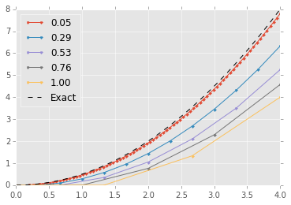

```python
#define trivial test function
def test_func(t,y):
    return t

#calculate Euler method for many h and plot
for h in np.linspace(.05,1,5):
    t,y = euler_method(test_func,4,0,0,h)
    plt.plot(t,y,'.-',label = '{:4.2f}'.format(h))

#calculate exact answer
t_known = np.linspace(0,4,100)
y_known = t_known**2/2
plt.plot(t_known,y_known,'--',color='black',label = 'Exact')
plt.legend(loc=2);
```

It is clear that as $h$ gets smaller, the solution approaches the exact solution. This method in general gets better for smaller $h$. For strictly concave up function, the Euler method will always underestimate the function at any point (except the intial points). The converse is true for a concave down function.

Let us see how this does with a more complicated function. Take $$\frac{dy}{dt}=y+t^2,$$ where $y(0)=0$. The solution to this equation can be found as $$y = 2e^t-t^2-2t-2$$ We will run the same code as before with this new function

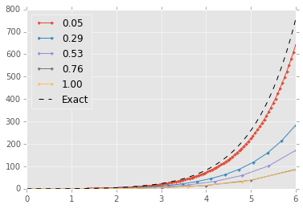

```python
#define trivial test function
def test_func_2(t,y):
    return y+t**2

#calculate Euler method for many h and plot
for h in np.linspace(.05,1,5):
    t,y = euler_method(test_func_2,6,0,0,h)
    plt.plot(t,y,'.-',label = '{:4.2f}'.format(h))

#calculate exact answer
t_known = np.linspace(0,6,100)
y_known = 2*np.exp(t_known)-t_known**2-2*t_known-2
plt.plot(t_known,y_known,'--',color='black',label = 'Exact')
plt.legend(loc=2);
```

Additionally, this method without any modifications cannot solve second order differential equations although any ordinary second order differntial equation can be converted into two first order differential equations which can be solved using the Euler method. However, we will move on to other methods.

## Leafrog Method

The leapfrog method is commonly used to solve second order equation and is usually framed in terms of equations of motion. It is a seoncd order method and so is stable for more tpes of problems. The setup is that we have an equation of the form $$ \frac{d^2x}{dt^2}= F(x),$$ or also $$\frac{dv}{dt}=F(x)$$, where $v=dx/dt$. Here our second order derivative is only a function of the positions, not of time. We must update both $x$ and $v$ in order to find the solution and can define the update equations as $$ x_{n} = x_{n-1}+v_{n-1}\Delta t + \frac{1}{2}F(x_{n-1})(\Delta t)^2$$

$$v_{n}=v_{n-1}+\frac{1}{2}(F(x_{n-1})+F(x_n))\Delta t,$$

where $\Delta t$ is the time step, equivalent to $h$ in the Euler step.

Since this solves a second order We first update the equations for position and then for velocity. Notice that these equations are interdependant and thus we are effectively "leapfrogging" over these coordinates. We implement this below.

```python
def leapfrog_method(f,t_final,t_0,x_0,v_0,dt):
    """function to compute leapfrog method for function f from t_0 to t_final
    with initial condition x(t_0)=x_0,v(t_0)=v_0"""
    #find number of steps
    steps = int((t_final-t_0)/dt)
    #declare array of zeros for answer
    x = np.zeros(steps)
    v = np.zeros(steps)
    t = np.linspace(t_0,t_final,steps)
    x[0] = x_0
    v[0] = v_0
    for i in range(1,steps):
        #first update x
        x[i] = x[i-1]+v[i-1]*dt + f(x[i-1])*dt**2/2
        #now update v
        v[i] = v[i-1]+(f(x[i-1])+f(x[i]))*dt/2
    return t,v,x
```

For a very simple example of this, consider an object dropped and under the force of gravity. Here we can use Newton's law $F=ma$ and the fact that $F=mg$ ($g\approx -9.8$m/s$^2$) for an object action under gravity to find that $$a=\frac{dx^2}{dt^2} = g$$ Clearly, this has a trivial solution as $$x(t) = x_0 + v_0t + \frac{g}{2}t^2.$$ Lets see how well this method performs. We will start with intitial conditions $x(0)=0,v(0)=100$ for 20 seconds.

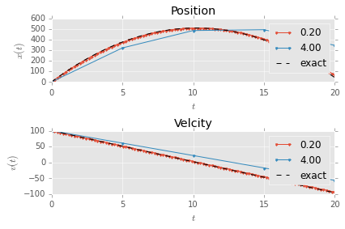

```python
def g(x):return -9.8
fig, ax = plt.subplots(2,1)
for dt in np.linspace(.2,4,2):
    t,v,x = leapfrog_method(g,20,0,0,100,dt)
    ax[0].plot(t,x,'.-',label ='{:4.2f}'.format(dt) )
    ax[1].plot(t,v,'.-',label='{:4.2f}'.format(dt))
#compute exact answer and plot
tk = np.linspace(0,20,100)
xk = 100 * tk -9.8/2*tk**2
vk = 100 -9.8*tk
ax[0].plot(tk,xk,'--',color='black',label = 'exact')
ax[1].plot(tk,vk,'--',color='black',label = 'exact')
#clean up plots
ax[0].set_xlabel(r'$t$')
ax[0].set_ylabel(r'$x(t)$')
ax[1].set_xlabel(r'$t$')
ax[1].set_ylabel(r'$v(t)$')
ax[0].set_title('Position')
ax[1].set_title('Velcity')
ax[0].legend()
ax[1].legend()
plt.tight_layout()
```

This method does quite well for moderately small step sizes and sucessfully computes both position and velocity. However, we will now move on to a more complicated problem and we will in turn use some of the scipy solvers to get a more exact answer.

## SciPy Solvers

Often when solving physical problems, we will have a set of coupled Ordinary Differential Equations. If these equations happen to be linear, then solving them can actually be quite easy analytically. Thus, it offers us a good example a system which we can learn to use the numerical solvers, while still having solutions which are known.

Consider the following coupled ODE $$ \frac{dy}{dt} = - x$$ $$\frac{dx}{dt} = 4y,$$ and our goal is to find $x(t),y(t)$ given some initial conditions $x(0),y(t)$. If you like, you can consider $t$ time. We will not going into the theory of ODE here, but in general, these linear systems can be solved by constructing a matrix representation of the equations, diagonalizing this matrix and constructing a solution out of the eigenvalues and eigenvectors (with some complexities for degeneracies). In this case, the matrix in the $(y,x)$ basis, $$ \begin{pmatrix} 0 &-1\\ 4&0 \end{pmatrix}, $$ which will have eigenvalues when $\lambda^2 = -4$ which implies that $\lambda=\pm 2i$. The eigenvectors can be written as $v_1 = (i/2,1)^T, v_2 = (-i/2,1)^T$. This allows us to write the solution as $$ y(t) = c_2\frac{i}{2}e^{2i t} -c_1\frac{i}{2}e^{-2it}$$ $$ x(t) = c_2e^{2i t} +c_1e^{-2it},$$ where $c_1,c_2$ are determined from the intital condtitions.

Now we consider the specific case that $x(0)=y(0)=1$. Then we can solve for the initital coefficients as $$1 = \frac{i}{2}c_2 - \frac{i}{2}c_1$$ $$1 = c_2 + c_1,$$ which implies that $c_2 = 1-c_1$ and thus $$1 = \frac{i}{2}(1-c_1) - \frac{i}{2}c_1=\frac{i}{2}-ic_1,$$ which can be solved as $c_1 = i+\frac{1}{2}$. Therefore, $c_2 = 1/2-i$

Thus our specific solutions are $$ y(t) = \left(\frac{1}{2}-i\right)\frac{i}{2}e^{2i t} -\left(i+\frac{1}{2}\right)\frac{i}{2}e^{-2it}$$ $$ x(t) = \left(\frac{1}{2}-i\right)e^{2i t} +\left(i+\frac{1}{2}\right)e^{-2it}.$$

These equations can be simplified, if we multiply out the terms, we get $$y(t)=\frac{i}{4} e^{2it} + \frac{1}{2}e^{2it} +\frac{1}{2}e^{-2it} - \frac{i}{4}e^{-2it}$$ $$x(t) = \frac{1}{2}e^{2it} - i e^{2it} + ie^{-2it} + \frac{1}{2}e^{-2it},$$

and finally using the definition of trigonometric functions as exponentials, we have $$y(t)=\cos(2t) - \frac{1}{2}\sin(2t)$$ $$x(t) = \cos(2t) +2\sin(2t),$$ which are real solutions!

In python, the imaginary number $\sqrt{-1}$ is represented as 1j. This is common in other fields such as electricial engineering and stems from electrical engineers wanting to use $i$ for current and not get confused it confused with the imaginary $i$.

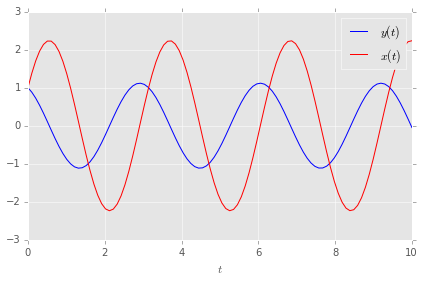

```python
t_ex = np.linspace(0,10,100)
y_ex = np.cos(2*t_ex) - np.sin(2*t_ex)/2
x_ex = np.cos(2*t_ex) +2*np.sin(2*t_ex)
fig , ax = plt.subplots(1,1)
ax.plot(t_ex,y_ex,'b',label = r'$y(t)$')
ax.plot(t_ex,x_ex,'r',label = r'$x(t)$')
ax.set_xlabel(r'$t$')
ax.legend()
plt.tight_layout()
```

Now we will numerically solve these equations using the ode solver from scipy. For this solver, one must write a function with inputs t,y args which represents the system of ode's one wants to solve and return a vector for each of the derivative components. So in our case, this is somewhat confusing since the y referenced as a variable to the function represents the entire differential equation vector, not the $y$ function we defined. We will return a vector of the form [dy/dt,dx/dt]. Then we can intialize the starting state and integrate.

Many examples online for this sort of solver use a timestep specified by the user. This is usually fine as long as the step size is long enough, however, it doesn't utilize the full power of these solvers, which is that they can adaptiveily change the step size such that they do as few function evaluations as possible while maintainging an accurate solution. In my personal experience, this can make a huge difference in the cases where one needs to solve the differential equations repeatedly which might need to be done when investigating the effects of altering the intital conditions, or optimizing parameters in a model.

here we will solve the system and then plot the solutions in the same way as before. Here we also plot points at which the integrator evaluated the function.

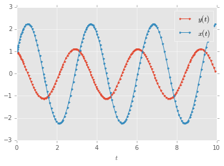

```python
from scipy.integrate import ode
def f(t,y):
    return [-y[1],4*y[0]]
#intialize solver with handling for complex numbers
solver = ode(f).set_integrator('vode')
#create intital condition
y0 = [1,1]
#set intital condition
solver.set_initial_value(y0,0)
#create vector hold our solutions
ans = []
#loop and solve differential equation step by step
while solver.successful() and solver.t < 10:
    #add solution from previous integration
    ans.append([solver.t,solver.y])
    solver.integrate(10, step = True)

t_num = np.asarray([i[0] for i in ans])
y_num = np.asarray([i[1][0] for i in ans])
x_num = np.asarray([i[1][1] for i in ans])
fig , ax = plt.subplots(1,1)
ax.plot(t_num,y_num,'.-',label = r'$y(t)$')
ax.plot(t_num,x_num,'.-',label = r'$x(t)$')

ax.set_xlabel(r'$t$')
ax.legend();
```

Now we will plot the solutions together.

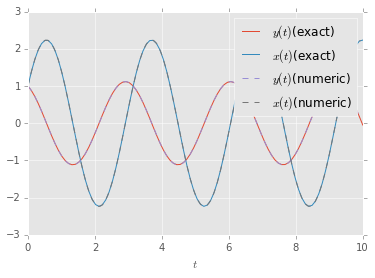

```python
fig , ax = plt.subplots(1,1)
ax.plot(t_ex,y_ex,label = r'$y(t)$(exact)')
ax.plot(t_ex,x_ex,label = r'$x(t)$(exact)')
ax.plot(t_num,y_num,'--',label = r'$y(t)$(numeric)')
ax.plot(t_num,x_num,'--',label = r'$x(t)$(numeric)')
ax.set_xlabel(r'$t$')
ax.legend();
```

We can see the numerical solution exactly matches the analytical one.